# Social Network Analysis - Exercise 1

Pair05 - Michelle Greaves - Tania El Achkar

On this first exercise, we will learn the basic functions of the Igraph package, a great tool to use Social Network Analysis metrics in our projects. We will use in this first exercise a dataset, “mathoverflow-ints.txt”, containing interactions between MathOverflow users with the next information:

- Answers to questions
- Comments to questions
- Comments to answers

You have to complete the code chunks in this document but also analyze the results, extract insights and describe them in an understandable way.

Please, write all your conclusions in blue

Both exercises may be done individually or in pairs; do not forget to write the name of the members of the team at the beginning of this document and also your team number in the name of this file (exercise1_PXX.Rmd)

## Loading data

In this section, the goal is loading the dataset given for this exercise, building the graph object and analyzing basics metrics.

- Build the graph object with all the interactions. Include the timestamp and the type of the edge as edge attributes.
- Describe the values provided by summary function on the graph object.
- Validate the graph has been created correctly comparing with the information after reading the file.
- Simplify the graph in order to remove loops and multiple edges. After simplifying the graph, a weight attribute should have been created, counting the number of interactions between two users.

```r
# Loading the dataset
data <- read.table("/Users/taniaelachkar/Desktop/Social Networks Analysis/Assignment 1/mathoverflow-ints.txt")
head(data)
```

```
##   V1 V2         V3  V4
## 1  1  4 1254192988 a2q
## 2  3  4 1254194656 a2q
## 3  1  2 1254202612 a2q
## 4 25  1 1254232804 a2q
## 5 14 16 1254263166 a2q
## 6  1 16 1254271943 a2q
```

```r
class(data)  # it's a data frame
```

```
## [1] "data.frame"
```

```r
colnames(data) <- c('v1','v2','timestamp','type')

# Building the graph object
g <- graph.data.frame(data, directed=TRUE)
g
```

```
## IGRAPH 0b69b26 DN-- 24818 506550 --
## + attr: name (v/c), timestamp (e/n), type (e/c)
## + edges from 0b69b26 (vertex names):
##  [1] 1   ->4  3   ->4  1   ->2  25  ->1  14  ->16 1   ->16 22  ->16
##  [8] 1   ->2  3   ->16 2   ->1  27  ->1  13  ->16 1   ->28 21  ->1
## [15] 1   ->7  32  ->1  7   ->27 32  ->1  32  ->27 1450->22 37  ->1
## [22] 37  ->1  1   ->2  37  ->1  32  ->1  19  ->16 40  ->2  42  ->2
## [29] 2   ->32 2   ->32 45  ->3  45  ->32 40  ->7  45  ->44 40  ->42
## [36] 50  ->27 50  ->16 1   ->44 54  ->44 45  ->44 3   ->56 19  ->44
## [43] 60  ->32 42  ->40 42  ->1  65  ->2  65  ->4  65  ->3  40  ->2
## [50] 1   ->44 66  ->65 3   ->66 37  ->65 45  ->1  65  ->2  66  ->1
## + ... omitted several edges
```

```r
# Describing the values provided by summary function on the graph object
summary(g)
```

```
## IGRAPH 0b69b26 DN-- 24818 506550 --
## + attr: name (v/c), timestamp (e/n), type (e/c)
```

```r
# Validating the graph has been created correctly
nrow(data)
```

```
## [1] 506550
```

```r
ecount(g)  # the number of edges in the graph (506550) is equal to the number of observations in the dataset
```

```
## [1] 506550
```

```r
v1v2 <- c(data$v1, data$v2)
length(unique(v1v2))  # 24818
```

```
## [1] 24818
```

```r
vcount(g)  # the number of nodes in the graph (24818) is equal to the number of unique values between v1 and v2, implying that the information is the same and that the graph has been created correctly
```

```
## [1] 24818
```

```r
# Simplifying the graph in order to remove loops and multiple edges
E(g)$weight <- 1
gs <- simplify(g, remove.multiple = TRUE, remove.loops = TRUE, edge.attr.comb=list(weight="sum"))
is.simple(gs)  # checking whether the graph is actually simple -> returns TRUE
```

```
## [1] TRUE
```

```r
is.weighted(gs)  # checking whether the weight attribute exists -> returns TRUE
```

```
## [1] TRUE
```

```r
vcount(gs)  # there are 24818 vertices
```

```
## [1] 24818
```

```r
ecount(gs)  # there are 227991 edges
```

```
## [1] 227991
```

```r
summary(gs)
```

```
## IGRAPH 7834998 DNW- 24818 227991 --
## + attr: name (v/c), timestamp (e/x), type (e/x), weight (e/n)
```

## Analyzing the graph

In this section, we will use Igraph functions to analyze some basic features:

- Is the graph connected? If it is not, compute the connected components and analyze the statistical distribution of the size of the resulting components. Do this considering all the links but also using only the different types of edges.
- Analyze the statistical distribution of the “weight” attribute created in the previous section and fit it to a power law distribution. Does it fit well enough?

```r
# For the rest of the assignment, we're using the simplified graph created above

# Checking whether the graph is connected
is_connected(gs)  # this returns FALSE, meaning that the graph is not connected
```

```
## [1] FALSE
```

```r
# Computing the connected components
css <- clusters(gs)
# I couldn't find another way to do this one

# Analysing the statistical distribution of the size of the resulting components
css$csize
```

```
##   [1] 24668     3     1     1     2     2     1     1     1     2     2
##  [12]     1     1     2     1     2     2     2     2     2     1     2
##  [23]     2     1     2     2     3     2     2     1     1     2     2
##  [34]     3     2     1     2     2     2     1     1     2     2     1
##  [45]     1     2     2     2     1     2     1     1     2     2     2
##  [56]     2     2     1     1     1     2     1     1     2     1     2
##  [67]     1     1     1     1     1     1     1     1     1     1     1
##  [78]     1     2     2     1     1     1     1     1     1     1     1
##  [89]     1     1     1     1     2     1     1     2     1     1     1
## [100]     1     2     1     1     1
```

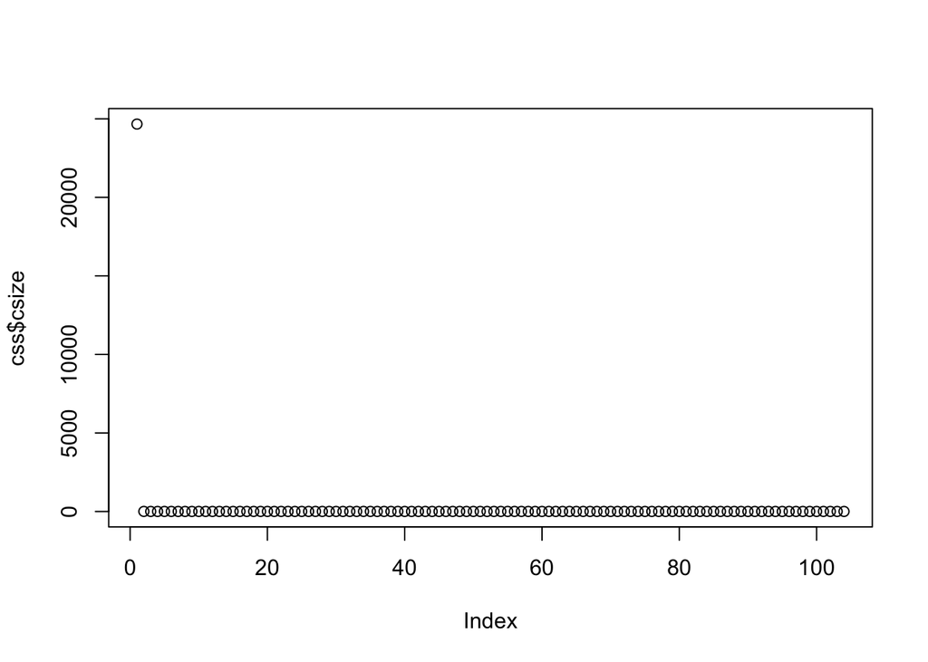

```r
plot(css$csize, by=gs$type)  # this plot shows that the distribution of the size of the components is not normally distributed. In fact, one cluster has a size of 24668 nodes, while the other clusters have a size ranging from 1 to 3 nodes and don't appear distinctly from zero on the plot because they're very close to zero, especially compared to the value of 24668 that significantly increases the scale of the graph
```

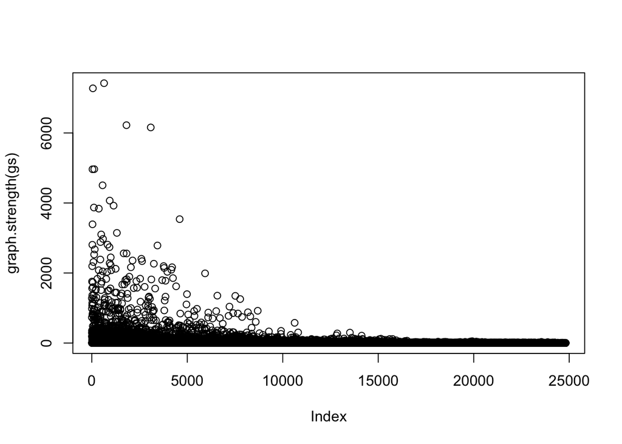

```r
# Analysing the statistical distribution of the "weight" attribute
plot(graph.strength(gs))
```

```r
# Fitting it to a power law distribution
att <- edge_attr(gs)
fit <- fit_power_law(att$weight)
fit$KS.p  # the p-value is 0.018, which is less than 0.05, meaning that we reject the test hypothesis that the original data could have been drawn from the fitted power-law distribution. Therefore no, it doesn't fit well enough because it didn't come from a power-law distribution, which we can confirm by looking at the graph of the weight attribute
```

```
## [1] 0.01863459
```